# Kaleb Swift: STAT 184 Final Project

## Guiding Question

My guiding question in this project was: do more developed countries have more women’s rights? By intuition, I believe that more developed nations would tend to have higher GDP per captita, national GDP growth, and higher life expectancies, so I paid extra attention to those variables when looking at the data table of World Development Indicators (WDI). Also by intuition, I believe that countries with more women’s rights would tend to have a higher prevalence of modern contraceptive methods, women having higher education (for example, at least a Bachelor’s degree) at a rate more similar to that of men, and a higher percentage of women would be in the work force. Because of this, I looked for those variables in the Gender Statistics data table (GS).

## The Data

Here, I load the necessary packages for this project.

```r
library(DataComputing)
library(tidyr)
```

Here, I load the data. It is from the World Bank website’s free data tables page.

```r
wdi_data <- read.csv("5422156d-7638-42dd-85e4-2aaf0a8ae0b6_Data.csv", header=TRUE, na.strings=c("","NA","..", " "))
gs_data <- read.csv("8f79c865-4e73-43e3-a534-351fdca8f75d_Data.csv", header=TRUE, na.strings=c("","NA","..", " "))
```

Here, I examine the number of rows in each column and peek at the heads of the data tables.

```r
wdi_data %>% na.omit() %>% nrow()
```

```
[1] 9276
```

```r
gs_data %>% na.omit() %>% nrow()
```

```
[1] 15191
```

```r
head(wdi_data)
```

|  | Country.Name | Country.Code | Series.Name | Series.Code | X2009..YR2009. | X2010..YR2010. | X2011..YR2011. | X2012..YR2012. | X2013..YR2013. | X2014..YR2014. | X2015..YR2015. | X2016..YR2016. | X2017..YR2017. | X2018..YR2018. |
| --- | --- | --- | --- | --- | --- | --- | --- | --- | --- | --- | --- | --- | --- | --- |
| 1 | Argentina | ARG | Adolescent fertility rate (births per 1,000 women ages 15-19) | SP.ADO.TFRT | 63.189600 | 63.315400 | 63.441200 | 63.567000 | 63.410000 | 63.253000 | 63.096000 | 62.939000 | 62.782000 | NA |
| 2 | Argentina | ARG | Agriculture, forestry, and fishing, value added (% of GDP) | NV.AGR.TOTL.ZS | 5.273623 | 7.132167 | 6.998734 | 5.781744 | 6.052918 | 6.712704 | 5.156686 | 6.264566 | 5.478382 | 6.140206 |
| 3 | Argentina | ARG | Annual freshwater withdrawals, total (% of internal resources) | ER.H2O.FWTL.ZS | NA | NA | NA | 12.907534 | NA | 12.907534 | NA | NA | NA | NA |
| 4 | Argentina | ARG | Births attended by skilled health staff (% of total) | SH.STA.BRTC.ZS | 97.900000 | 94.970000 | 97.140000 | 98.200000 | 97.040000 | 99.600000 | 99.600000 | NA | NA | NA |
| 5 | Argentina | ARG | CO2 emissions (metric tons per capita) | EN.ATM.CO2E.PC | 4.445388 | 4.607164 | 4.644373 | 4.609180 | 4.498540 | 4.781508 | NA | NA | NA | NA |
| 6 | Argentina | ARG | Contraceptive prevalence, any methods (% of women ages 15-49) | SP.DYN.CONU.ZS | NA | NA | NA | 55.400000 | 81.300000 | NA | NA | NA | NA | NA |

```r
head(gs_data)
```

|  | Series.Name | Series.Code | Country.Name | Country.Code | X2009..YR2009. | X2010..YR2010. | X2011..YR2011. | X2012..YR2012. | X2013..YR2013. | X2014..YR2014. | X2015..YR2015. | X2016..YR2016. | X2017..YR2017. | X2018..YR2018. |
| --- | --- | --- | --- | --- | --- | --- | --- | --- | --- | --- | --- | --- | --- | --- |
| 1 | Ratio of female to male labor force participation rate (%) (modeled ILO estimate) | SL.TLF.CACT.FM.ZS | Afghanistan | AFG | 51.56037 | 51.67223 | 52.45901 | 53.48682 | 54.66827 | 55.89811 | 57.11075 | 58.10454 | 59.00813 | 59.24465 |
| 2 | Ratio of female to male labor force participation rate (%) (modeled ILO estimate) | SL.TLF.CACT.FM.ZS | Albania | ALB | 69.90761 | 72.54700 | 73.13036 | 73.81763 | 71.27351 | 70.11208 | 73.16646 | 72.94539 | 72.79217 | 72.73358 |
| 3 | Ratio of female to male labor force participation rate (%) (modeled ILO estimate) | SL.TLF.CACT.FM.ZS | Algeria | DZA | 20.37520 | 20.52794 | 21.93041 | 23.44040 | 24.04946 | 22.75762 | 22.52406 | 22.26486 | 22.01880 | 22.12334 |
| 4 | Ratio of female to male labor force participation rate (%) (modeled ILO estimate) | SL.TLF.CACT.FM.ZS | American Samoa | ASM | NA | NA | NA | NA | NA | NA | NA | NA | NA | NA |
| 5 | Ratio of female to male labor force participation rate (%) (modeled ILO estimate) | SL.TLF.CACT.FM.ZS | Andorra | AND | NA | NA | NA | NA | NA | NA | NA | NA | NA | NA |
| 6 | Ratio of female to male labor force participation rate (%) (modeled ILO estimate) | SL.TLF.CACT.FM.ZS | Angola | AGO | 93.55195 | 93.58976 | 93.53113 | 93.55563 | 93.65208 | 93.76980 | 93.90388 | 93.97804 | 94.10319 | 94.16260 |

## Data Wrangling

Here, I trim out the country code so that the data tables are a little easier to look at. I do this by selecting everything but the country code. I also made sure to select things in the same order so the two tables would appear more similar. When viewing wdi_data and gs_data, I also noticed that there were some rows that didn’t have a series or code, or at least had some other gibberish. To remedy this, I created a RE to filter out all rows that had something in the Series.code variable that were not of the proper form.

```r
wdi <- wdi_data %>%
  filter(grepl("([.]*\\.)*[.]*", Series.Code)) %>%
  select(Country.Name, Series.Name, Series.Code, X2009..YR2009., X2010..YR2010., X2011..YR2011., X2012..YR2012., X2013..YR2013., X2014..YR2014., X2015..YR2015., X2016..YR2016., X2017..YR2017., X2018..YR2018.) %>%
  mutate(yr2009=X2009..YR2009., yr2010=X2010..YR2010., yr2011=X2011..YR2011., yr2012=X2012..YR2012., yr2013=X2013..YR2013., yr2014=X2014..YR2014., yr2015=X2015..YR2015., yr2016=X2016..YR2016., yr2017=X2017..YR2017., yr2018=X2018..YR2018., country=Country.Name, series=Series.Name, code=Series.Code) %>%
  select(country, series, code, yr2009, yr2010, yr2011, yr2012, yr2012, yr2013, yr2014, yr2014, yr2015, yr2016, yr2017, yr2018)
gs <- gs_data %>%
  filter(grepl("([.]*\\.)*[.]*", Series.Code)) %>%
  select(Country.Name, Series.Name, Series.Code, X2009..YR2009., X2010..YR2010., X2011..YR2011., X2012..YR2012., X2013..YR2013., X2014..YR2014., X2015..YR2015., X2016..YR2016., X2017..YR2017., X2018..YR2018.) %>%
  mutate(yr2009=X2009..YR2009., yr2010=X2010..YR2010., yr2011=X2011..YR2011., yr2012=X2012..YR2012., yr2013=X2013..YR2013., yr2014=X2014..YR2014., yr2015=X2015..YR2015., yr2016=X2016..YR2016., yr2017=X2017..YR2017., yr2018=X2018..YR2018., country=Country.Name, series=Series.Name, code=Series.Code) %>%
  select(country, series, code, yr2009, yr2010, yr2011, yr2012, yr2012, yr2013, yr2014, yr2014, yr2015, yr2016, yr2017, yr2018)
```

Here, I wrangle the data into a single table: wdigs (because it is a combination of wdi and gs). Each of the smaller tables contains the data I want in regards to a particular series variable. I then join the smaller tables into two larges ones, wdi_2 and gs_2. To make wdigs, I join wdi_2 and gs_2. I now realize that I could have just made wdi_2 and gs_2 in one step each, but I already have everything working perfectly fine in the code below, so I decided to leave it as is.

For WDI variables, I looked at GDP per capita (wdi_GDP), national GDP growth (wdi_growth), and life expectancy (wdi_life).

For GS variables, I looked at contraceptive prevalence (gs_contra), female Bachelor’s degree ratio to population (gs_femBach), male Bachelor’s degree ration to population (gs_maleBach), and the percentage of the female population in the work force (gs_labor).

```r
# In each of the following data tables, years are changed to be a single column variable, and each series is made into a separate column variable. When I was performing the data wrangling, I was looking up each variable's code one at a time, and so I made the tables one at a time. I now realize that I could have just made wdi_2 and gs_2 in one step each, but I already have everything working perfectly fine in the code below, so I decided to leave it as is.
# This data table contains data about the GDP per capita for each country in each of the following years.
wdi_GDP <- wdi %>%
  filter(code=="NY.GDP.PCAP.PP.CD") %>%
  gather(key=yr, value=val, yr2009, yr2010, yr2011, yr2012, yr2013, yr2014, yr2015, yr2016, yr2017, yr2018) %>%
  spread(key=series, value=val)
# This data table contains data about the % change of national GDP for each country in each of the following years.
wdi_growth <- wdi %>%
  filter(code=="NY.GDP.MKTP.KD.ZG") %>%
  gather(key=yr, value=val, yr2009, yr2010, yr2011, yr2012, yr2013, yr2014, yr2015, yr2016, yr2017, yr2018) %>%
  spread(key=series, value=val)
# This data table contains data about the life expectancy at birth in each country for each of the following years.
wdi_life <- wdi %>%
  filter(code=="SP.DYN.LE00.IN") %>%
  gather(key=yr, value=val, yr2009, yr2010, yr2011, yr2012, yr2013, yr2014, yr2015, yr2016, yr2017, yr2018) %>%
  spread(key=series, value=val)
# This data table is a join of the previous three. It also edits the year variable to be just the year number.
wdi_2 <- wdi_GDP %>%
  left_join(wdi_growth, by=c("country"="country", "yr"="yr")) %>%
  left_join(wdi_life, by=c("country"="country", "yr"="yr")) %>%
  mutate(year = as.numeric(substring(yr, 3))) %>%
  select(country, year, `GDP per capita, PPP (current international $)`, `GDP growth (annual %)`, `Life expectancy at birth, total (years)`)
# This data table contains data about the prevalence of modern contraceptive methods in each country for each of the following years. It ended up being a very sparse data table, so its information is not used in analysis, as na.omit() removes too many rows when using this table.
gs_contra <- gs %>%
  filter(code=="SP.DYN.CONM.ZS") %>%
  gather(key=yr, value=val, yr2009, yr2010, yr2011, yr2012, yr2013, yr2014, yr2015, yr2016, yr2017, yr2018) %>%
  spread(key=series, value=val)
# This data table contains data about the % of the population that is a woman with at least a Bachelor's degree. It ended up being a very sparse data table, so its information is not used in analysis, as na.omit() removes too many rows when using this table.
gs_femBach <- gs %>%
  filter(code=="SE.TER.CUAT.BA.FE.ZS") %>%
  gather(key=yr, value=val, yr2009, yr2010, yr2011, yr2012, yr2013, yr2014, yr2015, yr2016, yr2017, yr2018) %>%
  spread(key=series, value=val)
# This data table contains data about the % of the population that is a man with at least a Bachelor's degree. It ended up being a very sparse data table, so its information is not used in analysis, as na.omit() removes too many rows when using this table.
gs_maleBach <- gs %>%
  filter(code=="SE.TER.CUAT.BA.MA.ZS") %>%
  gather(key=yr, value=val, yr2009, yr2010, yr2011, yr2012, yr2013, yr2014, yr2015, yr2016, yr2017, yr2018) %>%
  spread(key=series, value=val)
# this data table countains data about the % of the (15+) female population that is in the workforce for each country in each of the following years.
gs_labor <- gs %>%
  filter(code=="SL.TLF.CACT.FE.NE.ZS") %>%
  gather(key=yr, value=val, yr2009, yr2010, yr2011, yr2012, yr2013, yr2014, yr2015, yr2016, yr2017, yr2018) %>%
  spread(key=series, value=val)
# This data table is a join of the previous four. It also edits the year variable to be just the year number.
gs_2 <- gs_contra %>%
  left_join(gs_femBach, by=c("country"="country", "yr"="yr")) %>%
  left_join(gs_maleBach, by=c("country"="country", "yr"="yr")) %>%
  left_join(gs_labor, by=c("country"="country", "yr"="yr")) %>%
  mutate(year = as.numeric(substring(yr, 3))) %>%
  select(country, year, `Contraceptive prevalence, modern methods (% of women ages 15-49)`, "Educational attainment, at least Bachelor's or equivalent, population 25+, female (%) (cumulative)",
"Educational attainment, at least Bachelor's or equivalent, population 25+, male (%) (cumulative)", `Labor force participation rate, female (% of female population ages 15+) (national estimate)`)
# Here, I join wdi_2 and gs_2. I also rename the variables so that they are easier to type.
wdigs <- wdi_2 %>% left_join(gs_2, by=c("country"="country", "year"="year"))
```

```
Column `country` joining factors with different levels, coercing to character vector
```

```r
names(wdigs) <- c("country", "year", "GDP_PC", "GDP_Growth", "Life_Expectancy", "Modern_Contraceptive_Prevalence", "Female_Bachelor", "Male_Bachelor", "Female_Labor")
```

Here, I visualize Female Employment rate against GDP per capita and life expectancy. Each dot in the graph is the average of a country’s GDP per capita, life expectancy, and female population % participation in the workforce over the years 2009-2018.

The data about Bachelor’s degrees and contraceptive prevalence ended up being incredibly sparse, so I felt it was unfortunately necessary to ignore those variables when doing analysis so that I would still have a good number of cases.

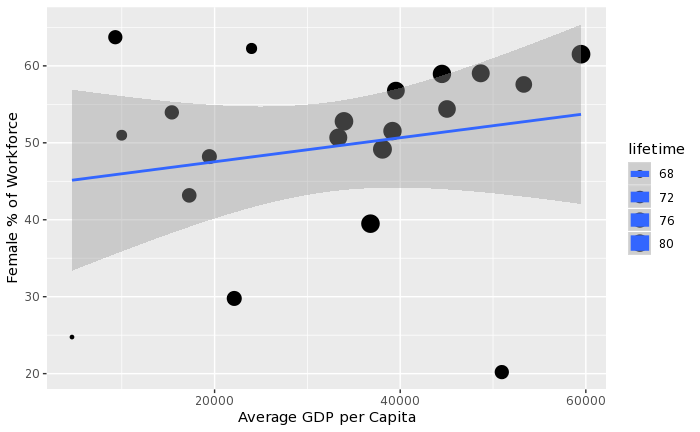

```r
# The data about contraceptives and Bachelor's degrees was too sparse, so I decided to make a graph instead of use machine learning. I did my analysis based on GDP per captita, national GDP growth %, life expectancy, and female population % participation in labor. National GDP growth % ended up not being very correlated, so I did not include it in my graph.
cases <- wdigs %>%
  select(country, year, GDP_PC, GDP_Growth, Life_Expectancy, Female_Labor) %>%
  na.omit() %>% group_by(country) %>%
  summarise(avg_GDP_PC = mean(GDP_PC), avg_Growth = mean(GDP_Growth), lifetime=mean(Life_Expectancy), F_employment = mean(Female_Labor))
# Each dot in the graph is the average of a country's GDP per capita, life expectancy, and female population % participation in the workforce over the years 2009-2018.
ggplot(data=cases,aes(x=avg_GDP_PC,y=F_employment))+geom_point()+aes(size=lifetime) + stat_smooth(method=lm) + xlab("Average GDP per Capita") + ylab("Female % of Workforce")
```